# FAO livestock density rasters (GoC)

Counts of **qualifying untreated municipal wastewater discharge points** (CNGMD receptors: river/stream, ground/ravine, canal/drain, ocean, beach, estuary/marsh), as used in CW WWPS scoring.

- **Region map:** number of points per OHI region (latest census year)
- **Municipality table:** number of points per municipality (same year; no local municipio polygons for a map)

```r
library(tidyverse)
library(sf)
library(here)
library(scales)
library(grid)

pick_existing <- function(...) {
  paths <- unlist(list(...), use.names = FALSE)
  hit <- paths[file.exists(paths)]
  if (length(hit) == 0) NA_character_ else hit[[1]]
}

normalize_rgn_id <- function(x) {
  x %>% as.character() %>% str_squish() %>% str_replace_all(" ", "_")
}

rgn_labels <- c(
  "Region_1" = "Western Upper Gulf",
  "Region_2" = "Western Midriff Islands",
  "Region_3" = "Western Central Gulf",
  "Region_4" = "Western Southern Gulf",
  "Region_5" = "Eastern Upper Gulf",
  "Region_6" = "Eastern Midriff Islands",
  "Region_7" = "Southern Sonora Coast",
  "Region_8" = "Sinaloa Coast",
  "Region_9" = "Southeastern Gulf"
)

# red = most points, blue = least (same CW ramp as pressure maps)
count_palette <- rev(c(
  "#8a0032", "#A50026", "#A50026", "#D73027", "#F46D43",
  "#FDAE61", "#FEE090", "#FEE090", "#ABD9E9", "#4575B4", "#313695"
))

cw_root <- "/home/shares/ohi/OHI_GOC/goal_prep/cw/v2025"
local_ww <- here::here("cw_mazu/v2025/chemicals/agua_sin_tratamiento")

density_path <- pick_existing(
  file.path(cw_root, "agua_sin_tratamiento/output/density_goc_discharge_points_per_km2.csv"),
  file.path(cw_root, "chemicals/agua_sin_tratamiento/output/density_goc_discharge_points_per_km2.csv"),
  file.path(local_ww, "output/density_goc_discharge_points_per_km2.csv")
)

all_years_path <- pick_existing(
  file.path(cw_root, "agua_sin_tratamiento/int/goc_aguaresd_all_years.csv"),
  file.path(cw_root, "chemicals/agua_sin_tratamiento/int/goc_aguaresd_all_years.csv"),
  file.path(local_ww, "int/goc_aguaresd_all_years.csv")
)

rgn_path <- pick_existing(
  "/home/shares/ohi/OHI_GOC/spatial/OHI_regions/goc_ohi_rgns.shp",
  "/home/shares/ohi/OHI_GOC/spatial/ohi_regions/goc_ohi_rgns.shp",
  here::here("spatial/ohi_regions/goc_ohi_rgns.shp")
)

stopifnot(!is.na(density_path), !is.na(all_years_path), !is.na(rgn_path))

regions <- st_read(rgn_path, quiet = TRUE) %>%
  mutate(rgn_id = normalize_rgn_id(rgn_id))
if ("location" %in% names(regions)) {
  regions <- regions %>% filter(location == "marine" | is.na(location))
}

# same receptor filter as script2_current_status.qmd
qualifying_receptors <- c(1L, 4L, 5L, 6L, 7L, 8L)

density <- read_csv(density_path, show_col_types = FALSE) %>%
  mutate(
    rgn_id = normalize_rgn_id(rgn_id),
    year = as.integer(census_year),
    n_points = as.integer(n_goc_discharge_points)
  )

# fill Region_2 (and any missing region-year) with 0 for map completeness
all_rgn <- names(rgn_labels)
all_years <- sort(unique(density$year))
density_full <- tidyr::expand_grid(rgn_id = all_rgn, year = all_years) %>%
  left_join(density %>% select(rgn_id, year, n_points, sites_per_km2), by = c("rgn_id", "year")) %>%
  mutate(n_points = replace_na(n_points, 0L))

latest_year <- max(density_full$year, na.rm = TRUE)
latest_rgn <- density_full %>% filter(year == latest_year)

map_dat <- regions %>%
  left_join(latest_rgn, by = "rgn_id") %>%
  mutate(rgn_label = unname(rgn_labels[rgn_id]))

cat("Density:", density_path, "\n")
```

```
Density: /home/shares/ohi/OHI_GOC/goal_prep/cw/v2025/chemicals/agua_sin_tratamiento/output/density_goc_discharge_points_per_km2.csv
```

```r
cat("All years:", all_years_path, "\n")
```

```
All years: /home/shares/ohi/OHI_GOC/goal_prep/cw/v2025/chemicals/agua_sin_tratamiento/int/goc_aguaresd_all_years.csv
```

```r
cat("Regions:", rgn_path, "\n")
```

```
Regions: /home/shares/ohi/OHI_GOC/spatial/OHI_regions/goc_ohi_rgns.shp
```

```r
cat("Latest census year:", latest_year, "\n")
```

```
Latest census year: 2023
```

## Region map (point counts)

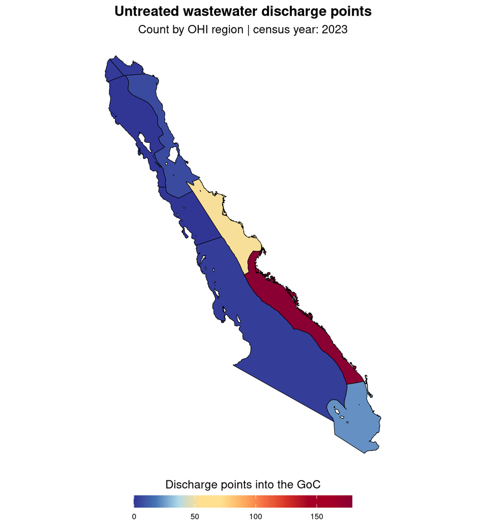

```r
p_rgn <- ggplot() +
  geom_sf(data = map_dat, aes(fill = n_points), color = "black", linewidth = 0.25) +
  scale_fill_gradientn(
    colours = count_palette,
    limits = c(0, max(latest_rgn$n_points, na.rm = TRUE)),
    breaks = pretty(c(0, max(latest_rgn$n_points, na.rm = TRUE)), n = 5),
    na.value = "grey90",
    name = "Discharge points into the GoC",
    guide = guide_colorbar(
      title.position = "top",
      barwidth = unit(8, "cm"),
      barheight = unit(0.45, "cm")
    )
  ) +
  labs(
    title = "Untreated wastewater discharge points",
    subtitle = paste0(
      "Count by OHI region | census year: ", latest_year
    )
  ) +
  theme_void(base_size = 12) +
  theme(
    plot.title = element_text(face = "bold", hjust = 0.5),
    plot.subtitle = element_text(hjust = 0.5),
    legend.position = "bottom",
    legend.title = element_text(hjust = 0.5),
    legend.text = element_text(size = 8)
  )

p_rgn
```

```r
k <- latest_rgn %>%
  mutate(rgn_label = unname(rgn_labels[rgn_id])) %>%
  arrange(desc(n_points)) %>%
  select(rgn_id, rgn_label, year, n_points) %>%
  knitr::kable()

k
```

| rgn_id | rgn_label | year | n_points |
| --- | --- | --- | --- |
| Region_8 | Sinaloa Coast | 2023 | 179 |
| Region_7 | Southern Sonora Coast | 2023 | 52 |
| Region_9 | Southeastern Gulf | 2023 | 23 |
| Region_6 | Eastern Midriff Islands | 2023 | 6 |
| Region_4 | Western Southern Gulf | 2023 | 2 |
| Region_1 | Western Upper Gulf | 2023 | 1 |
| Region_5 | Eastern Upper Gulf | 2023 | 1 |
| Region_2 | Western Midriff Islands | 2023 | 0 |
| Region_3 | Western Central Gulf | 2023 | 0 |

## Counts over time by region

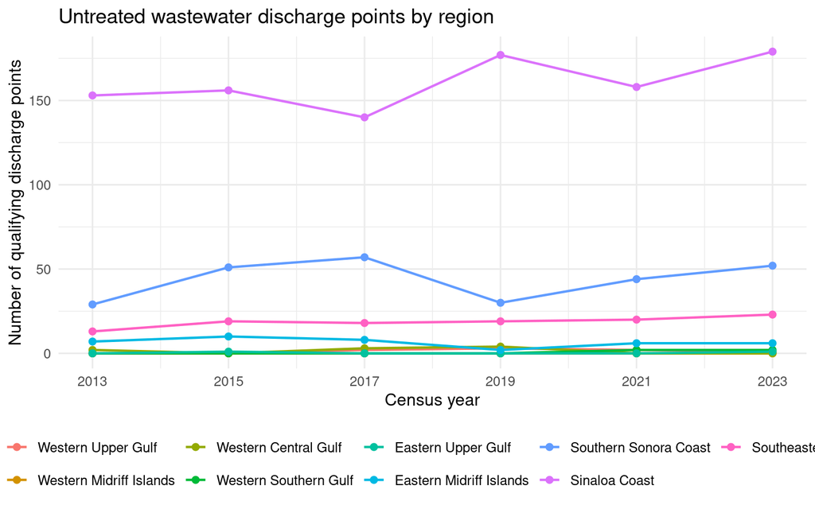

```r
ggplot(density_full, aes(x = year, y = n_points, color = rgn_id, group = rgn_id)) +
  geom_line(linewidth = 0.8) +
  geom_point(size = 2) +
  scale_x_continuous(breaks = all_years) +
  scale_color_manual(
    values = setNames(
      scales::hue_pal()(length(all_rgn)),
      all_rgn
    ),
    labels = rgn_labels,
    name = NULL
  ) +
  labs(
    title = "Untreated wastewater discharge points by region",
    x = "Census year",
    y = "Number of qualifying discharge points"
  ) +
  theme_minimal(base_size = 12) +
  theme(legend.position = "bottom")
```

## Municipality counts (latest year)

Same qualifying receptors; each census row is one discharge point. Municipality polygons for a choropleth live on Mazu (`mex_admin2_joined_w_municipio_codigos.shp`); this table uses the cleaned CNGMD extract.

```r
mun_latest <- read_csv(all_years_path, show_col_types = FALSE) %>%
  filter(
    census_year == latest_year,
    res_trec_std %in% qualifying_receptors
  ) %>%
  mutate(rgn_id = normalize_rgn_id(rgn_id)) %>%
  count(
    rgn_id,
    entidad,
    descrip_ent,
    mnpio,
    descrip_mun,
    name = "n_points"
  ) %>%
  mutate(rgn_label = unname(rgn_labels[rgn_id])) %>%
  arrange(desc(n_points))

mun_latest %>%
  select(rgn_id, rgn_label, descrip_ent, descrip_mun, mnpio, n_points) %>%
  knitr::kable()
```

| rgn_id | rgn_label | descrip_ent | descrip_mun | mnpio | n_points |
| --- | --- | --- | --- | --- | --- |
| Region_8 | Sinaloa Coast | Sinaloa | ahome | 25001 | 52 |
| Region_8 | Sinaloa Coast | Sinaloa | guasave | 25011 | 42 |
| Region_8 | Sinaloa Coast | Sinaloa | navolato | 25018 | 24 |
| Region_8 | Sinaloa Coast | Sinaloa | el fuerte | 25010 | 22 |
| Region_7 | Southern Sonora Coast | Sonora | cajeme | 26018 | 18 |
| Region_9 | Southeastern Gulf | Jalisco | tuxpan | 14108 | 14 |
| Region_8 | Sinaloa Coast | Sinaloa | angostura | 25002 | 12 |
| Region_8 | Sinaloa Coast | Sinaloa | san ignacio | 25016 | 12 |
| Region_7 | Southern Sonora Coast | Sonora | etchojoa | 26026 | 10 |
| Region_7 | Southern Sonora Coast | Sonora | san ignacio rio muerto | 26072 | 8 |
| Region_7 | Southern Sonora Coast | Sonora | bacum | 26012 | 7 |
| Region_7 | Southern Sonora Coast | Sonora | huatabampo | 26033 | 6 |
| Region_8 | Sinaloa Coast | Sinaloa | sinaloa | 25017 | 5 |
| Region_6 | Eastern Midriff Islands | Sonora | caborca | 26017 | 4 |
| Region_8 | Sinaloa Coast | Sinaloa | badiraguato | 25003 | 4 |
| Region_8 | Sinaloa Coast | Sinaloa | salvador alvarado | 25015 | 3 |
| Region_4 | Western Southern Gulf | Baja California Sur | la paz | 3003 | 2 |
| Region_7 | Southern Sonora Coast | Sonora | benito juarez | 26071 | 2 |
| Region_8 | Sinaloa Coast | Sinaloa | elota | 25008 | 2 |
| Region_9 | Southeastern Gulf | Nayarit | amatlan de canas | 18003 | 2 |
| Region_9 | Southeastern Gulf | Nayarit | tepic | 18017 | 2 |
| Region_1 | Western Upper Gulf | Baja California | mexicali | 2002 | 1 |
| Region_5 | Eastern Upper Gulf | Sonora | general plutarco elias calles | 26070 | 1 |
| Region_6 | Eastern Midriff Islands | Sonora | hermosillo | 26030 | 1 |
| Region_6 | Eastern Midriff Islands | Sonora | pitiquito | 26047 | 1 |
| Region_7 | Southern Sonora Coast | Sonora | guaymas | 26029 | 1 |
| Region_8 | Sinaloa Coast | Sonora | rosario | 26051 | 1 |
| Region_9 | Southeastern Gulf | Jalisco | cabo corrientes | 14020 | 1 |
| Region_9 | Southeastern Gulf | Jalisco | santa maria del oro | 14056 | 1 |
| Region_9 | Southeastern Gulf | Nayarit | compostela | 18004 | 1 |
| Region_9 | Southeastern Gulf | Nayarit | san blas | 18012 | 1 |
| Region_9 | Southeastern Gulf | Nayarit | tecuala | 18016 | 1 |

```r
library(tidyverse)
library(sf)
library(here)

pick_existing <- function(...) {
  paths <- unlist(list(...), use.names = FALSE)
  hit <- paths[file.exists(paths)]
  if (length(hit) == 0) NA_character_ else hit[[1]]
}

normalize_rgn_id <- function(x) {
  x %>% as.character() %>% str_squish() %>% str_replace_all(" ", "_")
}

gulf_turquoise <- "#2BBBAD"
state_fill <- "#d6cac0"

rgn_path <- pick_existing(
  "/home/shares/ohi/OHI_GOC/spatial/OHI_regions/goc_ohi_rgns.shp",
  "/home/shares/ohi/OHI_GOC/spatial/ohi_regions/goc_ohi_rgns.shp",
  here::here("spatial/ohi_regions/goc_ohi_rgns.shp")
)

states_path <- pick_existing(
  "/home/shares/ohi/OHI_GOC/spatial/ohi_regions/states.shp",
  "/home/shares/ohi/OHI_GOC/spatial/OHI_regions/states.shp",
  "/home/shares/ohi/OHI_GOC/spatial/ohi_regions/goc_states.shp",
  here::here("spatial/ohi_regions/states.shp"),
  here::here("spatial/ohi_regions/goc_states.shp")
)

stopifnot(!is.na(rgn_path))
if (is.na(states_path)) {
  warning("States shapefile not found; map will show regions only.")
}

regions <- st_read(rgn_path, quiet = TRUE) %>%
  mutate(rgn_id = normalize_rgn_id(rgn_id))
if ("location" %in% names(regions)) {
  regions <- regions %>% filter(location == "marine" | is.na(location))
}

states <- if (!is.na(states_path)) {
  st_read(states_path, quiet = TRUE)
} else {
  NULL
}

# match CRS so layers overlay cleanly
if (!is.null(states) && st_crs(states) != st_crs(regions)) {
  states <- st_transform(states, st_crs(regions))
}

cat("Regions:", rgn_path, "\n")
```

```
Regions: /home/shares/ohi/OHI_GOC/spatial/OHI_regions/goc_ohi_rgns.shp
```

```r
cat("States:", states_path, "\n")
```

```
States: NA
```

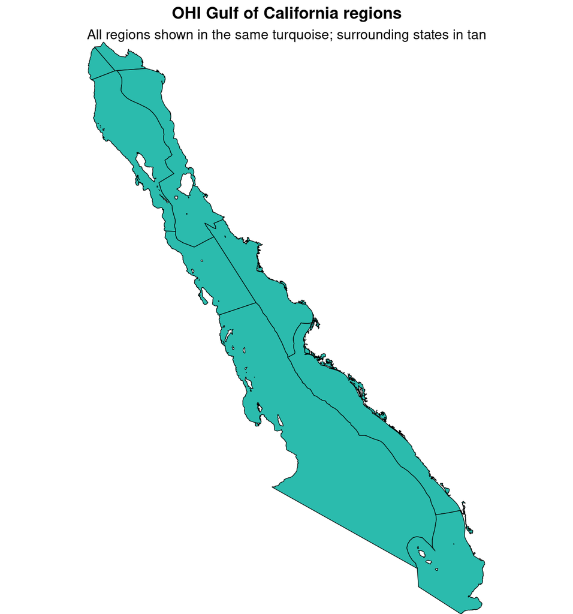

```r
p <- ggplot()

if (!is.null(states)) {
  p <- p +
    geom_sf(
      data = states,
      fill = state_fill,
      color = "grey40",
      linewidth = 0.12
    )
}

p <- p +
  geom_sf(
    data = regions,
    fill = gulf_turquoise,
    color = "black",
    linewidth = 0.25
  ) +
  labs(
    title = "OHI Gulf of California regions",
    subtitle = "All regions shown in the same turquoise; surrounding states in tan"
  ) +
  coord_sf(expand = FALSE) +
  theme_void(base_size = 12) +
  theme(
    plot.title = element_text(face = "bold", hjust = 0.5),
    plot.subtitle = element_text(hjust = 0.5)
  )

p
```

Static map of **FAO GLW4 2020 livestock density** (heads/km²) cropped to the Gulf of California.

Change `species` below to plot any of: `Bovino`, `Ave`, `Caprino`, `Porcino`, `Ovino`.

```r
library(tidyverse)
library(sf)
library(terra)
library(here)
library(scales)
library(grid)

# ---- choose livestock group ----
species <- "Bovino"   # Ave | Bovino | Caprino | Porcino | Ovino

pick_existing <- function(...) {
  paths <- unlist(list(...), use.names = FALSE)
  hit <- paths[file.exists(paths)]
  if (length(hit) == 0) NA_character_ else hit[[1]]
}

species_glw_map <- tribble(
  ~nomespecie, ~glw_file, ~label,
  "Bovino",  "GLW4-2020.D-DA.CTL.tif", "Cattle (Bovino)",
  "Ave",     "GLW4-2020.D-DA.CHK.tif", "Poultry (Ave)",
  "Caprino", "GLW4-2020.D-DA.GTS.tif", "Goats (Caprino)",
  "Porcino", "GLW4-2020.D-DA.PGS.tif", "Swine (Porcino)",
  "Ovino",   "GLW4-2020.D-DA.SHP.tif", "Sheep (Ovino)"
)

stopifnot(species %in% species_glw_map$nomespecie)
sp_meta <- species_glw_map %>% filter(nomespecie == species)

glw_dir <- pick_existing(
  "/home/shares/ohi/OHI_GOC/_raw_data/FAO_livestock_density/d2026",
  here::here("_raw_data/FAO_livestock_density/d2026")
)

glw_path <- if (!is.na(glw_dir)) {
  file.path(glw_dir, sp_meta$glw_file)
} else {
  NA_character_
}

rgn_path <- pick_existing(
  "/home/shares/ohi/OHI_GOC/spatial/OHI_regions/goc_ohi_rgns.shp",
  "/home/shares/ohi/OHI_GOC/spatial/ohi_regions/goc_ohi_rgns.shp",
  here::here("spatial/ohi_regions/goc_ohi_rgns.shp")
)

inland_path <- pick_existing(
  "/home/shares/ohi/OHI_GOC/spatial/inland_50km_buffer/inland_50km_goc.shp",
  here::here("spatial/inland_50km_buffer/inland_50km_goc.shp")
)

states_path <- pick_existing(
  "/home/shares/ohi/OHI_GOC/spatial/ohi_regions/states.shp",
  "/home/shares/ohi/OHI_GOC/spatial/OHI_regions/states.shp",
  here::here("spatial/ohi_regions/states.shp"),
  here::here("spatial/ohi_regions/goc_states.shp")
)

stopifnot(
  !is.na(glw_path), file.exists(glw_path),
  !is.na(rgn_path)
)

regions <- st_read(rgn_path, quiet = TRUE)
if ("location" %in% names(regions)) {
  regions <- regions %>% filter(location == "marine" | is.na(location))
}

inland <- if (!is.na(inland_path)) st_read(inland_path, quiet = TRUE) else NULL
states <- if (!is.na(states_path)) st_read(states_path, quiet = TRUE) else NULL

# GoC mask: inland 50 km + marine regions when available; else region bbox
goc_mask <- if (!is.null(inland)) {
  bind_rows(
    st_transform(regions, st_crs(inland)),
    inland
  ) %>%
    st_make_valid() %>%
    st_union() %>%
    st_sf(geometry = .)
} else {
  regions %>%
    st_make_valid() %>%
    st_union() %>%
    st_sf(geometry = .)
}

cat("Species:", species, "-", sp_meta$label, "\n")
```

```
Species: Bovino - Cattle (Bovino)
```

```r
cat("Raster:", glw_path, "\n")
```

```
Raster: /home/shares/ohi/OHI_GOC/_raw_data/FAO_livestock_density/d2026/GLW4-2020.D-DA.CTL.tif
```

```r
cat("Regions:", rgn_path, "\n")
```

```
Regions: /home/shares/ohi/OHI_GOC/spatial/OHI_regions/goc_ohi_rgns.shp
```

```r
cat("Inland 50 km:", inland_path, "\n")
```

```
Inland 50 km: /home/shares/ohi/OHI_GOC/spatial/inland_50km_buffer/inland_50km_goc.shp
```

```r
cat("States:", states_path, "\n")
```

```
States: NA
```

```r
# crop global GLW4 to GoC (same general approach as script3_livestock.qmd)
glw_raw <- terra::rast(glw_path)

mask_wgs84 <- st_transform(goc_mask, terra::crs(glw_raw))
glw_cropped <- terra::crop(glw_raw, vect(mask_wgs84))
glw_goc <- terra::mask(glw_cropped, vect(mask_wgs84))

# optional: also try a processed SIAP tonnes raster for the same species if present
siap_dir <- pick_existing(
  "/home/shares/ohi/OHI_GOC/goal_prep/cw/v2025/pharmaceuticals/livestock_int",
  "/home/shares/ohi/OHI_GOC/goal_prep/cw/v2025/chemicals/pharmaceuticals/livestock_int",
  here::here("cw_mazu/v2025/chemicals/pharmaceuticals/livestock_int")
)

# keep overlay layers in raster CRS
regions_r <- st_transform(regions, terra::crs(glw_goc))
states_r <- if (!is.null(states)) st_transform(states, terra::crs(glw_goc)) else NULL

# ggplot-friendly table (drop empty cells)
glw_df <- as.data.frame(glw_goc, xy = TRUE, na.rm = TRUE)
names(glw_df)[3] <- "density"
# drop zeros so sparse land reads cleaner (optional)
# glw_df <- glw_df %>% filter(density > 0)

cat("Cells with data:", nrow(glw_df), "\n")
```

```
Cells with data: 2431
```

```r
cat("Density range (heads/km2):",
    paste(round(range(glw_df$density, na.rm = TRUE), 2), collapse = " - "), "\n")
```

```
Density range (heads/km2): 0 - 95.76
```

## FAO GLW4 density (heads/km²)

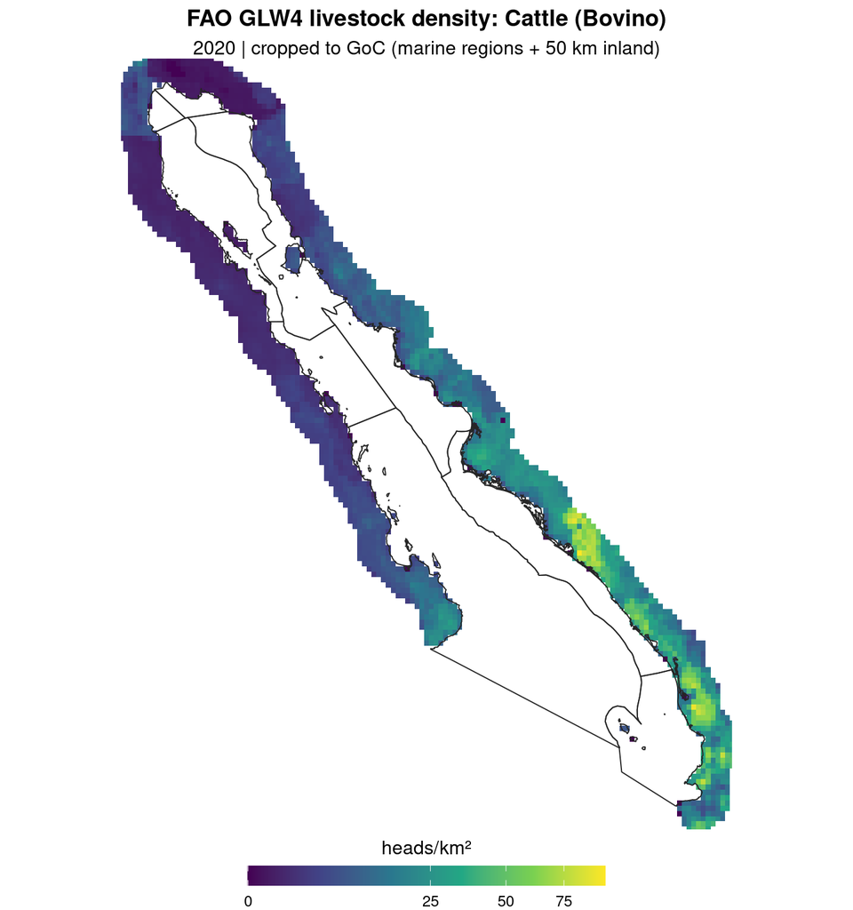

```r
p_glw <- ggplot()

if (!is.null(states_r)) {
  p_glw <- p_glw +
    geom_sf(
      data = states_r,
      fill = "#d6cac0",
      color = "grey40",
      linewidth = 0.12
    )
}

p_glw <- p_glw +
  geom_raster(
    data = glw_df,
    aes(x = x, y = y, fill = density),
    interpolate = FALSE
  ) +
  geom_sf(
    data = regions_r,
    fill = NA,
    color = "grey15",
    linewidth = 0.35
  ) +
  scale_fill_viridis_c(
    option = "D",
    trans = "sqrt",
    labels = label_comma(),
    name = "heads/km²",
    guide = guide_colorbar(
      title.position = "top",
      barwidth = unit(8, "cm"),
      barheight = unit(0.45, "cm")
    )
  ) +
  coord_sf(
    xlim = range(glw_df$x),
    ylim = range(glw_df$y),
    expand = FALSE,
    crs = terra::crs(glw_goc)
  ) +
  labs(
    title = paste0("FAO GLW4 livestock density: ", sp_meta$label),
    subtitle = "2020 | cropped to GoC (marine regions + 50 km inland)"
  ) +
  theme_void(base_size = 12) +
  theme(
    plot.title = element_text(face = "bold", hjust = 0.5),
    plot.subtitle = element_text(hjust = 0.5),
    legend.position = "bottom",
    legend.title = element_text(hjust = 0.5)
  )

p_glw
```

## Optional: SIAP dasymetric tonnes (if already written on Mazu)

Looks for `siap_tons_1km_{Species}_{year}.tif` from `script3_livestock.qmd`. Uses the latest year found for the selected species.

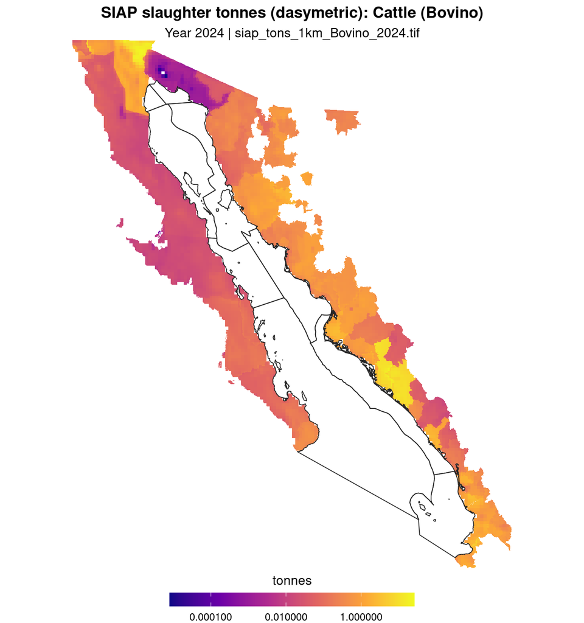

```r
siap_files <- if (!is.na(siap_dir) && dir.exists(siap_dir)) {
  list.files(
    siap_dir,
    pattern = paste0("^siap_tons_1km_", species, "_[0-9]{4}\\.tif$"),
    full.names = TRUE
  )
} else {
  character(0)
}

if (length(siap_files) == 0) {
  cat("No SIAP tonnes rasters found for", species, "in", siap_dir, "\n")
  cat("Skip this section, or run script3_livestock.qmd first.\n")
} else {
  siap_years <- as.integer(str_extract(basename(siap_files), "[0-9]{4}"))
  latest_siap <- siap_files[which.max(siap_years)]
  latest_yr <- max(siap_years, na.rm = TRUE)

  siap_r <- terra::rast(latest_siap)
  siap_df <- as.data.frame(siap_r, xy = TRUE, na.rm = TRUE)
  names(siap_df)[3] <- "tonnes"
  siap_df <- siap_df %>% filter(tonnes > 0)

  regions_s <- st_transform(regions, terra::crs(siap_r))
  states_s <- if (!is.null(states)) st_transform(states, terra::crs(siap_r)) else NULL

  p_siap <- ggplot()
  if (!is.null(states_s)) {
    p_siap <- p_siap +
      geom_sf(data = states_s, fill = "#d6cac0", color = "grey40", linewidth = 0.12)
  }
  p_siap <- p_siap +
    geom_raster(data = siap_df, aes(x = x, y = y, fill = tonnes), interpolate = FALSE) +
    geom_sf(data = regions_s, fill = NA, color = "grey15", linewidth = 0.35) +
    scale_fill_viridis_c(
      option = "C",
      trans = "log10",
      labels = label_comma(),
      name = "tonnes",
      guide = guide_colorbar(
        title.position = "top",
        barwidth = unit(8, "cm"),
        barheight = unit(0.45, "cm")
      )
    ) +
    coord_sf(
      xlim = range(siap_df$x),
      ylim = range(siap_df$y),
      expand = FALSE,
      crs = terra::crs(siap_r)
    ) +
    labs(
      title = paste0("SIAP slaughter tonnes (dasymetric): ", sp_meta$label),
      subtitle = paste0("Year ", latest_yr, " | ", basename(latest_siap))
    ) +
    theme_void(base_size = 12) +
    theme(
      plot.title = element_text(face = "bold", hjust = 0.5),
      plot.subtitle = element_text(hjust = 0.5),
      legend.position = "bottom",
      legend.title = element_text(hjust = 0.5)
    )

  p_siap
}
```

Static maps of **FAO GLW4 2020 livestock density** (heads/km²) cropped to the Gulf of California, one plot each for **Ave**, **Caprino**, **Porcino**, and **Ovino**.

```r
library(tidyverse)
library(sf)
library(terra)
library(here)
library(scales)
library(grid)

pick_existing <- function(...) {
  paths <- unlist(list(...), use.names = FALSE)
  hit <- paths[file.exists(paths)]
  if (length(hit) == 0) NA_character_ else hit[[1]]
}

species_to_plot <- c("Ave", "Caprino", "Porcino", "Ovino")

species_glw_map <- tribble(
  ~nomespecie, ~glw_file, ~label,
  "Ave",     "GLW4-2020.D-DA.CHK.tif", "Poultry (Ave)",
  "Caprino", "GLW4-2020.D-DA.GTS.tif", "Goats (Caprino)",
  "Porcino", "GLW4-2020.D-DA.PGS.tif", "Swine (Porcino)",
  "Ovino",   "GLW4-2020.D-DA.SHP.tif", "Sheep (Ovino)",
  "Bovino",  "GLW4-2020.D-DA.CTL.tif", "Cattle (Bovino)"
) %>%
  filter(nomespecie %in% species_to_plot) %>%
  mutate(nomespecie = factor(nomespecie, levels = species_to_plot)) %>%
  arrange(nomespecie)

glw_dir <- pick_existing(
  "/home/shares/ohi/OHI_GOC/_raw_data/FAO_livestock_density/d2026",
  here::here("_raw_data/FAO_livestock_density/d2026")
)

rgn_path <- pick_existing(
  "/home/shares/ohi/OHI_GOC/spatial/OHI_regions/goc_ohi_rgns.shp",
  "/home/shares/ohi/OHI_GOC/spatial/ohi_regions/goc_ohi_rgns.shp",
  here::here("spatial/ohi_regions/goc_ohi_rgns.shp")
)

inland_path <- pick_existing(
  "/home/shares/ohi/OHI_GOC/spatial/inland_50km_buffer/inland_50km_goc.shp",
  here::here("spatial/inland_50km_buffer/inland_50km_goc.shp")
)

states_path <- pick_existing(
  "/home/shares/ohi/OHI_GOC/spatial/ohi_regions/states.shp",
  "/home/shares/ohi/OHI_GOC/spatial/OHI_regions/states.shp",
  here::here("spatial/ohi_regions/states.shp"),
  here::here("spatial/ohi_regions/goc_states.shp")
)

stopifnot(!is.na(glw_dir), !is.na(rgn_path))

regions <- st_read(rgn_path, quiet = TRUE)
if ("location" %in% names(regions)) {
  regions <- regions %>% filter(location == "marine" | is.na(location))
}

inland <- if (!is.na(inland_path)) st_read(inland_path, quiet = TRUE) else NULL
states <- if (!is.na(states_path)) st_read(states_path, quiet = TRUE) else NULL

goc_mask <- if (!is.null(inland)) {
  bind_rows(
    st_transform(regions, st_crs(inland)),
    inland
  ) %>%
    st_make_valid() %>%
    st_union() %>%
    st_sf(geometry = .)
} else {
  regions %>%
    st_make_valid() %>%
    st_union() %>%
    st_sf(geometry = .)
}

cat("GLW dir:", glw_dir, "\n")
```

```
GLW dir: /home/shares/ohi/OHI_GOC/_raw_data/FAO_livestock_density/d2026
```

```r
cat("Regions:", rgn_path, "\n")
```

```
Regions: /home/shares/ohi/OHI_GOC/spatial/OHI_regions/goc_ohi_rgns.shp
```

```r
cat("Inland 50 km:", inland_path, "\n")
```

```
Inland 50 km: /home/shares/ohi/OHI_GOC/spatial/inland_50km_buffer/inland_50km_goc.shp
```

```r
cat("States:", states_path, "\n")
```

```
States: NA
```

```r
crop_glw_goc <- function(glw_path, goc_mask) {
  glw_raw <- terra::rast(glw_path)
  mask_wgs84 <- st_transform(goc_mask, terra::crs(glw_raw))
  glw_cropped <- terra::crop(glw_raw, vect(mask_wgs84))
  terra::mask(glw_cropped, vect(mask_wgs84))
}

plot_glw <- function(glw_goc, label, regions, states = NULL) {
  regions_r <- st_transform(regions, terra::crs(glw_goc))
  states_r <- if (!is.null(states)) st_transform(states, terra::crs(glw_goc)) else NULL

  glw_df <- as.data.frame(glw_goc, xy = TRUE, na.rm = TRUE)
  names(glw_df)[3] <- "density"

  p <- ggplot()
  if (!is.null(states_r)) {
    p <- p +
      geom_sf(
        data = states_r,
        fill = "#d6cac0",
        color = "grey40",
        linewidth = 0.12
      )
  }

  p +
    geom_raster(
      data = glw_df,
      aes(x = x, y = y, fill = density),
      interpolate = FALSE
    ) +
    geom_sf(
      data = regions_r,
      fill = NA,
      color = "grey15",
      linewidth = 0.35
    ) +
    scale_fill_viridis_c(
      option = "D",
      trans = "sqrt",
      labels = label_comma(),
      name = "heads/km²",
      guide = guide_colorbar(
        title.position = "top",
        barwidth = unit(8, "cm"),
        barheight = unit(0.45, "cm")
      )
    ) +
    coord_sf(
      xlim = range(glw_df$x),
      ylim = range(glw_df$y),
      expand = FALSE,
      crs = terra::crs(glw_goc)
    ) +
    labs(
      title = paste0("FAO GLW4 livestock density: ", label),
      subtitle = "2020 | cropped to GoC (marine regions + 50 km inland)"
    ) +
    theme_void(base_size = 12) +
    theme(
      plot.title = element_text(face = "bold", hjust = 0.5),
      plot.subtitle = element_text(hjust = 0.5),
      legend.position = "bottom",
      legend.title = element_text(hjust = 0.5)
    )
}

glw_plots <- purrr::pmap(
  list(species_glw_map$glw_file, species_glw_map$label, as.character(species_glw_map$nomespecie)),
  function(glw_file, label, nomespecie) {
    glw_path <- file.path(glw_dir, glw_file)
    stopifnot(file.exists(glw_path))
    message("Preparing ", nomespecie, ": ", glw_path)
    glw_goc <- crop_glw_goc(glw_path, goc_mask)
    plot_glw(glw_goc, label, regions, states)
  }
)
names(glw_plots) <- as.character(species_glw_map$nomespecie)
```

## Ave

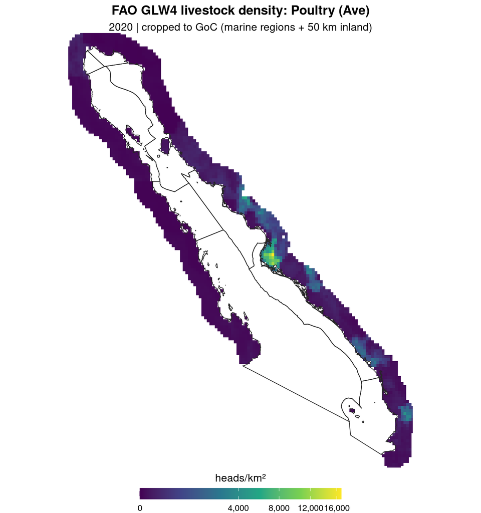

```r
glw_plots[["Ave"]]
```

## Caprino

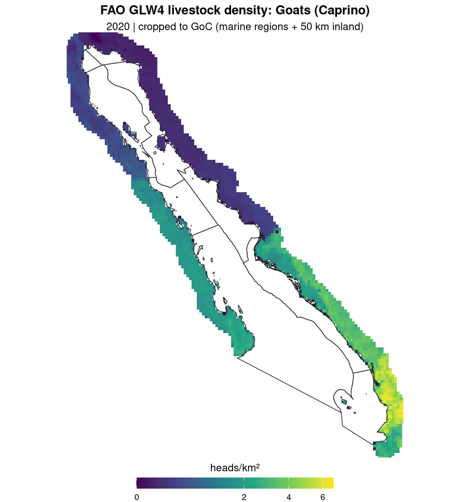

```r
glw_plots[["Caprino"]]
```

## Porcino

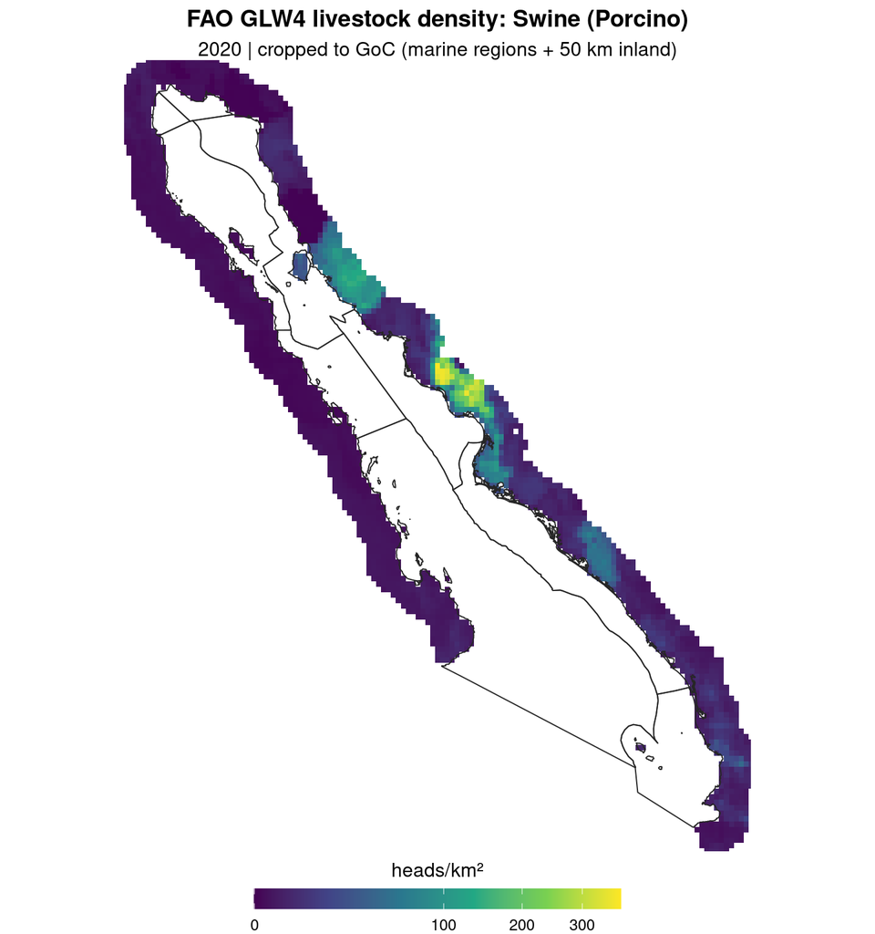

```r
glw_plots[["Porcino"]]
```

## Ovino

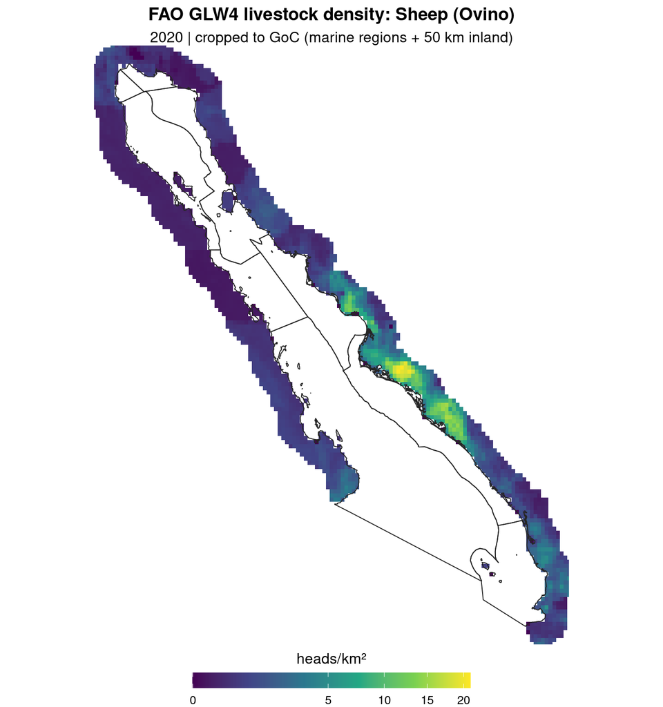

```r
glw_plots[["Ovino"]]
```